# Lab 01 - Hello R

### Exercise 4

Repeat the same analysis for away dataset.

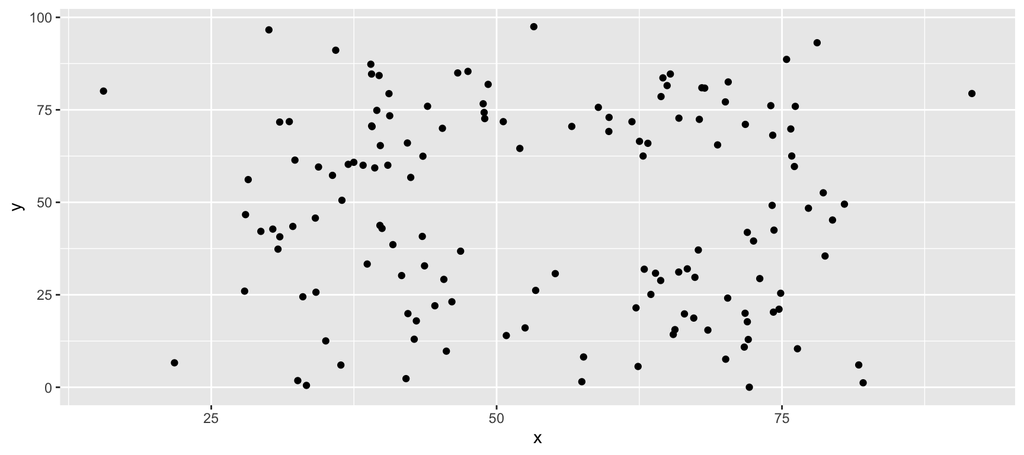

```r
away <- datasaurus_dozen %>%
  filter(dataset == "away")

ggplot(data = away, mapping = aes(x = x, y = y)) +
  geom_point()
```

The scatterplot shows a distinct pattern that is quite different from the dino and star shapes.

```r
away %>%
  summarize(r = cor(x, y))
```

```
## # A tibble: 1 × 1
##         r
##     <dbl>
## 1 -0.0641
```

The Pearson correlation coefficient is approximately r = -0.064, which still indicates a strongly weak negative correlation between x and y.

### Exercise 5

Visualize all 13 datasets at once and compare their correlation coefficients

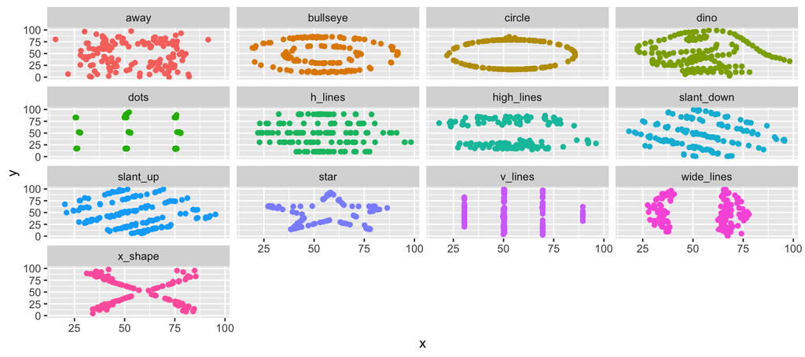

```r
ggplot(datasaurus_dozen, aes(x = x, y = y, color = dataset)) +
  geom_point() +
  facet_wrap(~dataset, ncol = 4) +
  theme(legend.position = "none")
```

```r
library(knitr)
datasaurus_dozen %>%
  group_by(dataset) %>%
  summarise(r = cor(x, y)) %>%
  knitr::kable(digits = 3, caption = "Correlation between x and y for all datasets")
```

Correlation between x and y for all datasets

| dataset | r |
| --- | --- |
| away | -0.064 |
| bullseye | -0.069 |
| circle | -0.068 |
| dino | -0.064 |
| dots | -0.060 |
| h_lines | -0.062 |
| high_lines | -0.069 |
| slant_down | -0.069 |
| slant_up | -0.069 |
| star | -0.063 |
| v_lines | -0.069 |
| wide_lines | -0.067 |
| x_shape | -0.066 |

As shown in the table above, all 13 datasets have a correlation coefficient very close to -0.06. Despite their drastically different visualization (dinos, stars, circles, etc.), they show similar relationship between x and y, which can be misleading on their own. This highlights the importance of data visualization and always visualizing data before analyzing it.